# Incarceration Rate by Race

Ximing Sun

2/25/2022

## Introduction

Racial discrimination is a universal problem. From the perspective of the world, as long as there are different races, there will be racial discrimination. White, black, yellow, European, American, Asian, there are different degrees of discrimination among each other, some with respect on the outside and contempt on the inside, some with deep hostility. According to the chart below, we find that the largest number of black race people in prison was in **2004**, with ( **1.7736^{4}**). Even today, the incarceration rate for blacks is about 0.4 percent (**0.0049136**). However, for whites, the incarceration rate was 0.1 percent (**0.0015731**). Regionally, the **WI** is probably the most discriminating state for blacks.Social unrest over racial discrimination has led to frequent protests.Therefore, I hope to use my data and charts on the **incarceration rate of black race from 1990 to 2018 to show the unequal treatment of black race** based on **black race prision admission rate** and **total black race people population**, so that the public can pay more attention to this problem and solve it fundamentally.

## Black Race versus White Race incarceration rates throughout the years the trend overtime

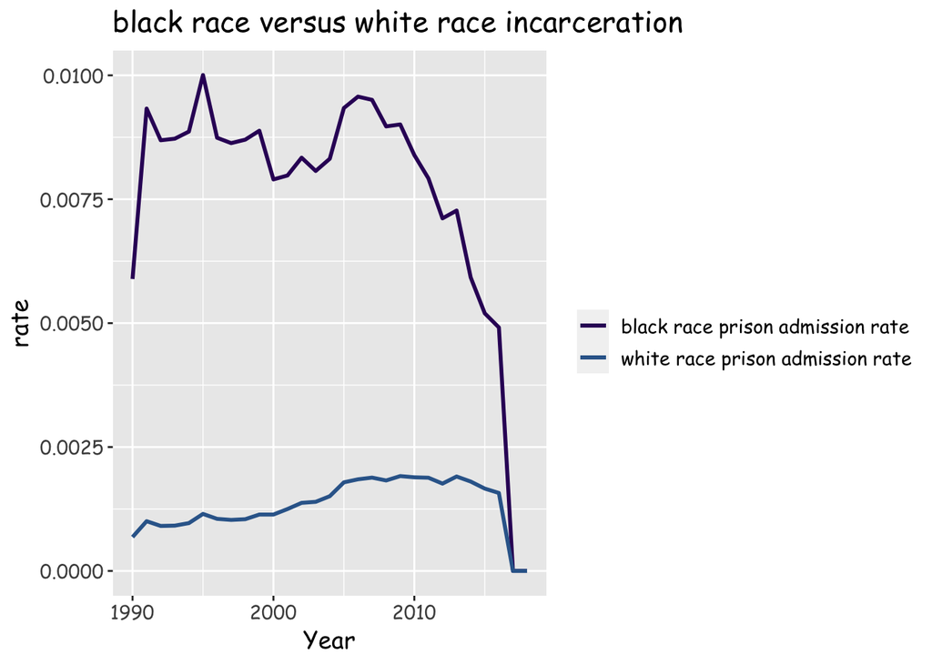

I was curious about the comparison of black and white incarceration rates from 1990 to the recent so I use the line chart which can better reflect the changes of these two variables over time a graph to show the huge difference between black and white incarceration rates, in order to reflect the serious problem of racial discrimination.

## Black Race Prison Admisson Rate Related to States

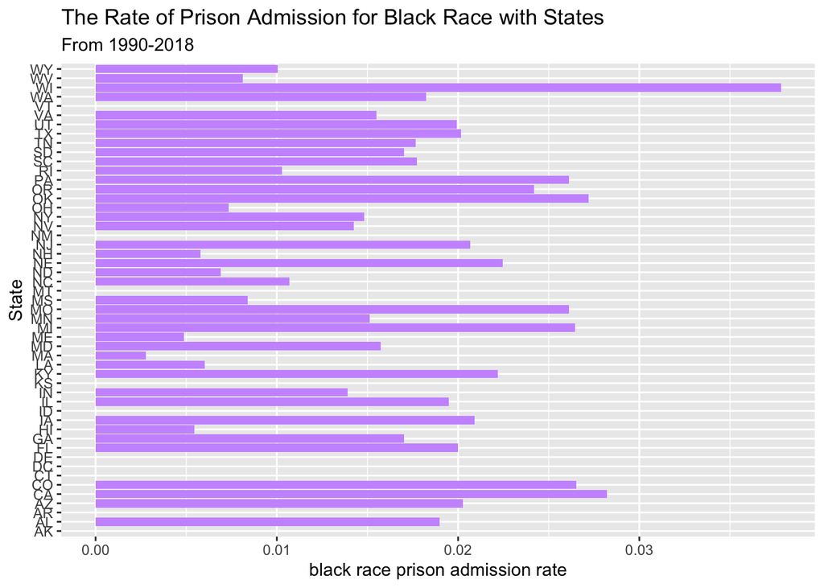

I am interested in the racial discrimination in each state of the United States, so I compare the incarceration rate of black people in each state to figure out which state has a high black incarceration rate, which can reflect the serious racial discrimination in which state. I used the horizontal bar chart here to see the size of the comparison, clearly show that the black race prison admisson rate in WI is much more higher that in the other states.

## Black Race incarcertion rate by region

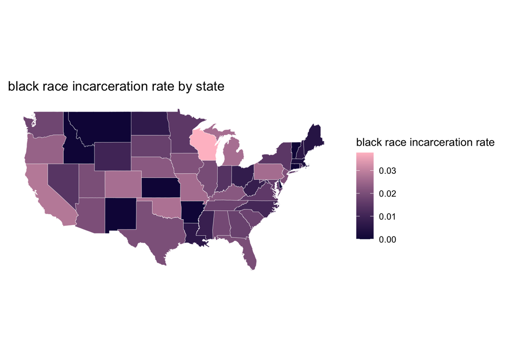

This map shows the black race incarceration rates in each state, with darker colors representing lower incarceration rates and lighter colors representing higher incarceration rates. Geographically, **WI** has the highest rate of black incarceration, reflecting racial discrimination in the state. Here, I hope to use my data and charts on the incarceration rate of black people from 1990 to 2018 to show the unequal treatment of black people, so that the public can pay more attention to this problem and solve it fundamentally.